# How do Social Factors Affect Learning Levels in Indian Govt. Schools?

### Kaveri Gita Nadhamuni - January 2015

[figure not shown]

I started by analyzing the 'National Achievement Survey' dataset which has 188,647 students’ records. These records include students' test scores in various subjects and responses to a questionnare on social factors in their lives. In this study I am comparing the performance of students on the basis of the following factors: Mother's education, Father's eduction, Watching TV, Library Usage, Age and Playing Sports.

# Summary of the dataset

The National Achievement test was taken by 188,647 students in 6,722 schools across 33 states and union territories of India. This test was administered to the 8th grade students of government schools in 2012; Most of the students were 13year olds. The number of students taking the survey is relatively higher in the southern states.

The intersting aspect of this survey is that it not only collected test scores in academic subjects but also conducted a questionnaire that collected information about the schools, teachers, and several other aspects of the students' home life and their socio-economic backgrounds.

# The Test Methodology

The National Achievement Survey (NAS) was conducted in a three stage sampling process. First, districts were selected based on the number of Class VIII students enrolled. Second, the requisite number of schools was selected. In most states, the sample size was around 250-300 schools. Finally, around 5000 Class VIII students were selected at random for each subject and tested.

```python
import pandas as pd
import numpy as np
import matplotlib.pyplot as plt
from pylab import *
from scipy.stats import norm
from numpy import linspace
from IPython.display import display, Image, HTML
#from talktools import website, nbviewer
%matplotlib inline

#Globals
filepath = '/Users/Kaveri/Documents/Project/National assesment dataset/'
subjects_df = pd.DataFrame({'Subject':     ['Language', 'Science', 'Social Science', 'Math'],
                           'Subject-Perf': ['readpcor', 'sciepcor', 'socspcor', 'mathpcor']},
                            index=[0,1,2,3])
```

```python
def summarize(filename, subject, subpcor):
    subject_data = pd.read_csv(filename)
    print 'Girls and Boys Data'
    print '_______________________'
    print ' '
    ntot = len(subject_data['STUID'])

    passmark = 40

    npass= len(subject_data[subject_data[subpcor]>=passmark])
    ppass= npass*100/ntot

    print 'Girls'
    girl = subject_data[subject_data['GENDER']=='Girl']
    ngirl = len(subject_data[subject_data['GENDER']=='Girl'])
    pgirl= ngirl*100/ntot
    print 'Number of Girls taking the subject:',ngirl,'(',pgirl,'%',')'

    npassgirl= len(girl[girl[subpcor]>=passmark])
    ppassgirl = npassgirl*100/ngirl
    nfailgirl= len(girl[girl[subpcor]<passmark])
    pfailgirl = nfailgirl*100/ngirl
    print 'Percentage of girls who passed:', ppassgirl, '%', '(', npassgirl, ')'
    print' '

    print 'Boys'
    boy = subject_data[subject_data['GENDER']=='Boy']
    nboy = len(subject_data[subject_data['GENDER']=='Boy'])
    pboy= nboy*100/ntot
    print 'Number of Boys who took the subject:',nboy,'(',pboy,'%',')'

    npassboy = len(boy[boy[subpcor]>=passmark])
    ppassboy = npassboy*100/nboy
    nfailboy = len(boy[boy[subpcor]<passmark])
    pfailboy = nfailboy*100/nboy
    print 'Percentage of boys who passed', ppassboy, '%','(',npassboy,')'
    print' '


    girl_fail_color='#e7aec4'
    girl_pass_color='#f78dc0'
    boy_fail_color='#59cbe2'
    boy_pass_color='#1ba7de'

    colorset = [girl_pass_color, girl_fail_color, boy_fail_color, boy_pass_color ]
    values = [npassgirl, nfailgirl, nfailboy, npassboy]
    labels = [(' '.join(map(str,('Girls who passed',':',npassgirl,'(',npassgirl*100/ntot,'%',')')))),
              (' '.join(map(str,('Girls who failed',':',nfailgirl,'(',nfailgirl*100/ntot,'%',')')))),
              (' '.join(map(str,('Boys who failed',':',nfailboy,'(',nfailboy*100/ntot,'%',')')))),
              (' '.join(map(str,('Boys who passed',':',npassboy,'(',npassboy*100/ntot,'%',')')))),
              ]
    plt.pie(values, labels=labels, colors= colorset)
    plt.title('Boys and girls who passed and failed')
    plt.show()
```

```python
# Read all NAS datafiles
read_df = pd.read_csv(filepath+'C8NAS_READ.csv')
read_students = len(read_df['STUID'])
math_df = pd.read_csv(filepath+'C8NAS_MATH .csv')
math_students = len(math_df['STUID'])
sci_df = pd.read_csv(filepath+'C8NAS_SCIE.csv')
sci_students = len(sci_df['STUID'])
socsci_df = pd.read_csv(filepath+'C8NAS_SOCS.csv')
socsci_students = len(math_df['STUID'])
pq_df = pd.read_csv(filepath+'C8NAS_PQ.csv')
pq_students = len(pq_df['STUID'])
```

```python
# Create a merged dataframe of all students
read_only_df = read_df.drop(['SCHID', 'state', 'DIST','SCH','STU','FORM','GENDER', 'AREA'], axis=1)
union_df = pd.merge(pq_df, read_only_df, on='STUID', how='outer')
math_only_df = math_df.drop(['SCHID', 'state', 'DIST','SCH','STU','FORM','GENDER', 'AREA'], axis=1)
union_df = pd.merge(union_df, math_only_df, on='STUID', how='outer')
sci_only_df = sci_df.drop(['SCHID', 'state', 'DIST','SCH','STU','FORM','GENDER', 'AREA'], axis=1)
union_df = pd.merge(union_df, sci_only_df, on='STUID', how='outer')
socsci_only_df = socsci_df.drop(['SCHID', 'state', 'DIST','SCH','STU','FORM','GENDER', 'AREA'], axis=1)
union_df = pd.merge(union_df, socsci_only_df, on='STUID', how='outer')
```

# Summary of asset test performance across states

The below color-density maps shows the performance of students across the 33 states and union territories of India (except the state of Assam, for which there is no data).

It is evident from the color density maps that the students seem to perform better in the 'language' subject than in the sciences and math. The students in the states of Uttar Pradesh and Madhya Pradesh seems to have performed consistenly well across the science and math subjects. Kerala which as a near 100% literacy rate seems to have performed pretty well across language, science and social science subjects. The state of Tamil Nadu which is the 2nd most urbanized state in the country with a literacy rate of 80.09% as per the 2011 census, has the lowest average marks scored in the asset test in science, social-science and math according to this survey! but this fact has been cross-checked with the results of the report [Reference 3] "What Students of Class VIII Know and Can Do - A summary of India's National Assessment Survey, Class VIII, 2012" by the NCERT Govt. of India.

[figure not shown]

Note: Refer to the legend for each of the maps since there are differences in the values for each map.

## Girls vs Boys Performance in NAS

Looking at the pie-chart below we can see that more girls(52%) took the test than boys(47%). Secondly the girls perfomed better than the boys. 60% of the girls who took the test passed, whereas only 56% of the boys who took the test passsed the test. This is consistent with my previous study of the Karnataka Xxtd board exam results, where the girls did better than the boys in every suject. See http://schoolworks.co.in/analytics/Girls-VS-Boys-Study-Oct26th-2014.html

```
Girls and Boys Data
_______________________

Girls
Number of Girls taking the subject: 50217 ( 52 % )
Percentage of girls who passed: 60 % ( 30150 )

Boys
Number of Boys who took the subject: 46291 ( 47 % )
Percentage of boys who passed 56 % ( 25962 )
```

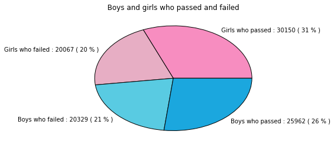

```python
summarize(filepath+'C8NAS_READ.csv','Language', 'readpcor')
```

```python
def students_by_factor_analysis(subject, subjectcode, factor_colname, factors, graph_colors, pie_title, pie_on,bar_title, bar_on):
    num_factors = len(factors)
    #print 'Total number of factors:', num_factors
    num_students_taking_subject=len(union_df[union_df[subjectcode]>=0])
    i = 0

    #making the empty dataframes to fill in the for loop
    bar_df = pd.DataFrame(columns=['factor', 'factor_percentage'])
    pie_values_df = pd.DataFrame(columns=['percentage'])
    pie_words_df  = pd.DataFrame(columns=['label'])

    #Making a for loop to calculate the values and words based on subject and factor
    for factor in factors.iteritems():
        #Calculating the number and percentage of students taking a subject based on the factor
        student_factor_df = union_df[union_df[factor_colname]==factors[i]]
        num_factor_students = len(student_factor_df[student_factor_df[subjectcode]>=0])
        factor_percentage=num_factor_students*100/num_students_taking_subject
        avg_percentage_correct= round(student_factor_df[subjectcode].mean(),2)
        bar_df.loc[i] = [factors[i], avg_percentage_correct]
        #Making the pie chart values and the pie chart labels
        pie_values_df.loc[i]= [factor_percentage]
        pie_words_df.loc[i]=[(' '.join(map(str,(factors[i],'(',factor_percentage,'%',')'))))]
        i=i+1

    #Generate Pie chart of breakup by factor
    pie_values=pie_values_df['percentage']
    pie_words=pie_words_df['label']
    if(pie_on == True):
        rcParams['figure.figsize'] = 6,3
        plt.rcParams['font.size'] = 14
        plt.pie(pie_values, labels = pie_words , colors=graph_colors)
        plt.title(pie_title)
        plt.show()
    #Generate Bar graph of performance by factor
    if(bar_on == True):
        bar_df.plot(x= 'factor', kind='bar', title = bar_title,color=graph_colors, legend=False)
        rcParams['figure.figsize'] = 6, 3
        rcParams['axes.labelsize'] = 14
        plt.ylim((20,60))
        #plt.rcParams['font.size'] = 11.0
        #factor_name = factor_name, ' values'
        #plt.xlabel('Factor Values')
        plt.show()
```

## Effect of Fathers' Education on Student Performance

Fathers' education in the survey is categorised into Illiterate, Primary-level, Secondary-level, Senior-secondary-level and Degree-and-above.

The pie chart below shows that the largest group of fathers in this category at 30% has a primary-level of education. Both illiterate and Secondary-level are next at 23%, followed by Senior-secondary level at 6% and Degree-and-above at only 3%.

The bar chart compares the students' performance in various subjects based on their father's level of education. As expected the students performance was best when the father's eduction level was degree-and-above and the students performed worst when the fathers were illiterate. This is not surprising because highly educated fathers are more likely to get involved and assist in their children's education. The disparity in father's education is seen most clearly in the Language subject. Interestingly, the education level of the father had the least impact on the math performance.

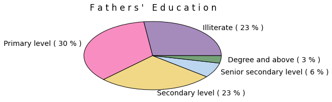

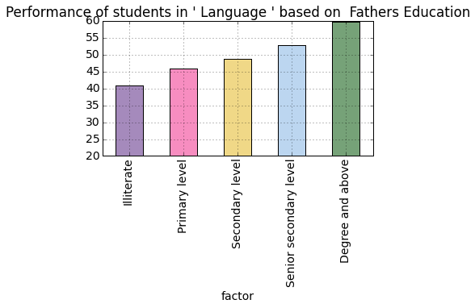

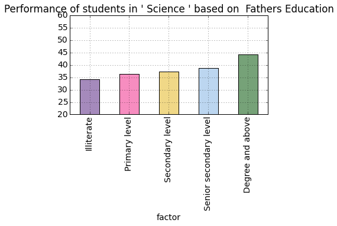

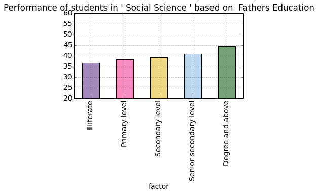

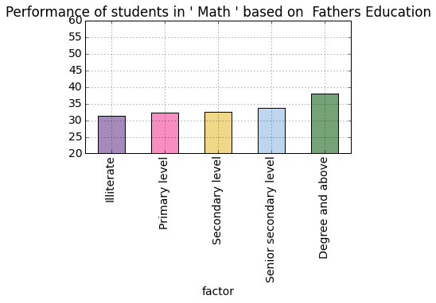

```python
#Performance of SCIENCE students depending on FATHERS EDUCATION LEVEL
factor_vals = pd.Series(['Illiterate','Primary level', 'Secondary level','Senior secondary level', 'Degree and above'])
pie_colors =('#a58abc','#f78dc0','#f0d887','#bcd6f0','#76a278')
factor_name      = 'Fathers Education'
factor_ques = 'PQ8a'

piechart_on = True
for sub in subjects_df.iterrows():
    ptitle = ' '.join(map(str,("Fathers' Education")))
    btitle = ' '.join(map(str,("\nPerformance of students in '",sub[1]['Subject'],"' based on ", factor_name)))
    students_by_factor_analysis(sub[1]['Subject'],sub[1]['Subject-Perf'], factor_ques, factor_vals, pie_colors, ptitle, piechart_on,btitle, True)
    if(piechart_on == True):
        piechart_on = False
```

### Effect of Mothers' Education on Student Performance

Mothers' education is also categorised into Illiterate, Primary-level, Secondary-level, Senior-secondary-level and Degree-and-above.

The bar chart compares students' performance in various subjects based on their mothers' level of education. Similar to fathers' education bar graphs, the children of mothers with degree-and-above did best and the children of illiterate mothers did worst. This disparity is seen most clearly in Language and least in Math.

It is generally acknowledged that when a woman is educated, her entire family benefits. It can be clearly seen here that such children do better in their studies.

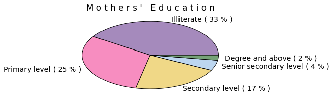

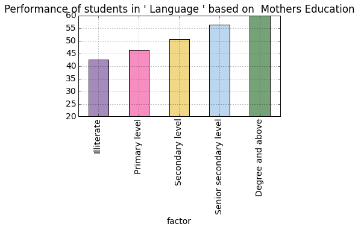

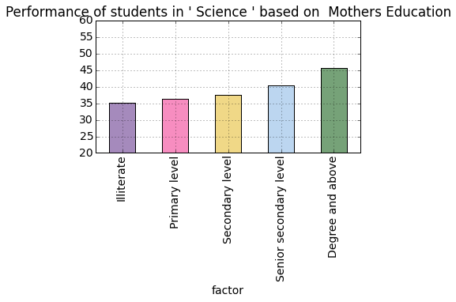

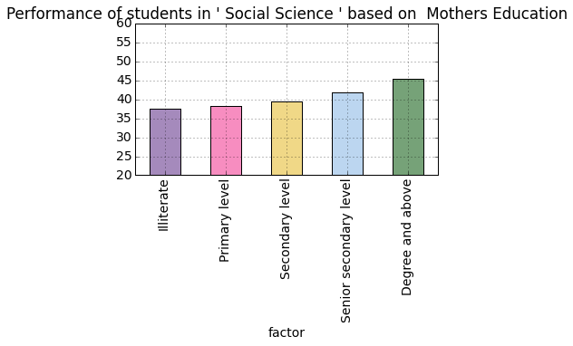

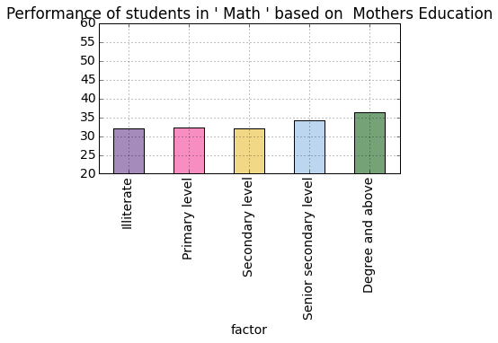

```python
#Performance of SCIENCE students depending on MOTHERS EDUCATION LEVEL
factor_vals = pd.Series(['Illiterate','Primary level', 'Secondary level','Senior secondary level', 'Degree and above'])
pie_colors =('#a58abc','#f78dc0','#f0d887','#bcd6f0','#76a278')
factor_name      = 'Mothers Education'
factor_ques = 'PQ8b'

piechart_on = True
for sub in subjects_df.iterrows():
    ptitle = ' '.join(map(str,("Mothers' Education")))
    btitle = ' '.join(map(str,("\nPerformance of students in '",sub[1]['Subject'],"' based on ", factor_name)))
    students_by_factor_analysis(sub[1]['Subject'],sub[1]['Subject-Perf'], factor_ques, factor_vals, pie_colors, ptitle, piechart_on,btitle, True)
    if(piechart_on == True):
        piechart_on = False
```

### Effect of Watching TV on Student Performance

Watching television is categorised into Daily, Once-a-Week, Once-a-Month and Never. As seen in the pie chart below, a huge majority, 63% of the students watch TV everyday. 20% watch TV once a week, 4% watch once a month and only 7% never watch TV.

The bar chart compares the students' performance in various subjects based on the amount of TV they watch. The children who watch TV every day did the best and those that never watched TV did the worst. This difference in performance is seen most clearly in Language.

Although there is a correlation between watching TV and doing well in studies, this may not be the causation. The reason for this better performance may not be watching TV everyday but the affluence that allows them to do so. Similarly, it could be that the students who never watch TV are also the ones who are less wealthy, and perform poorly in their academics due to factors like lack of motivation, support at home, access to books, good nutrition, etc. The causation may have more to do with their economic status than TV watching.

However in Math, the students who watched TV everyday did the worst, followed by students who never watched TV and then students who watch it once a month. The students who watch it once a week performed best in math. This is probably because watching TV helps students in their language and comprehension skills but excessive watching distracts them and reduces concentration impacting subjects like math which require more work.

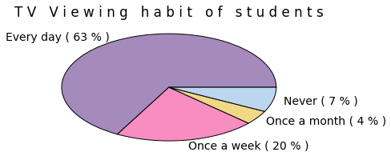

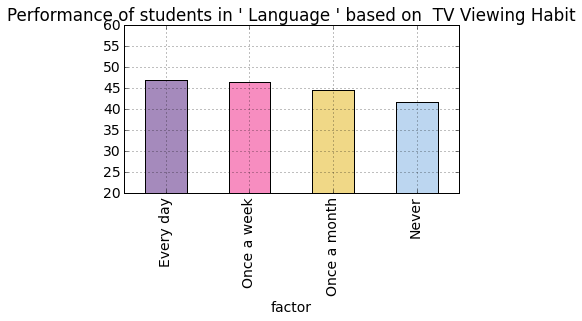

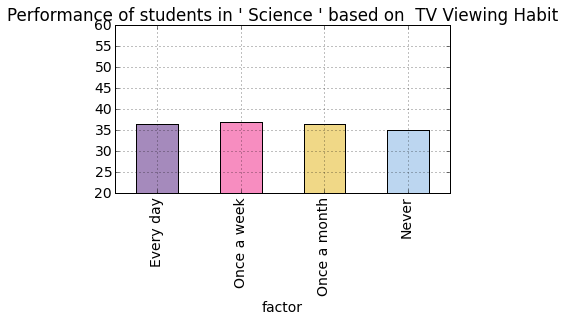

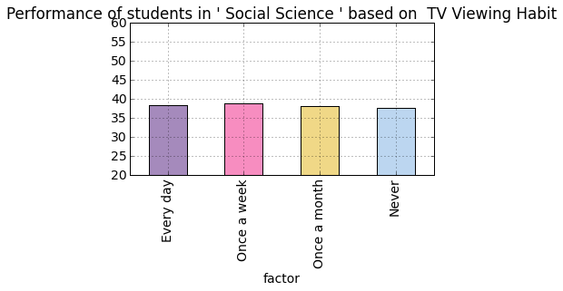

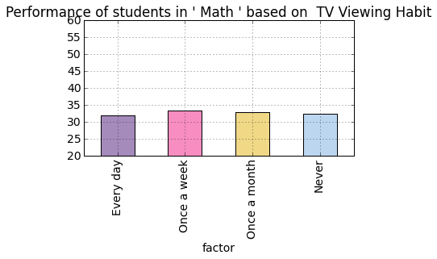

```python
#Performance of <subject> students depending on TV WATCHING HABIT
factor_vals = pd.Series(['Every day','Once a week', 'Once a month','Never'])
pie_colors =('#a58abc','#f78dc0','#f0d887','#bcd6f0','#76a278')
factor_name      = 'TV Viewing Habit'
factor_ques = 'PQ26a'

piechart_on = True
for sub in subjects_df.iterrows():
    ptitle = ' '.join(map(str,("TV Viewing habit of students")))
    btitle = ' '.join(map(str,("\nPerformance of students in '",sub[1]['Subject'],"' based on ", factor_name)))
    students_by_factor_analysis(sub[1]['Subject'],sub[1]['Subject-Perf'], factor_ques, factor_vals, pie_colors, ptitle, piechart_on,btitle, True)
    if(piechart_on == True):
        piechart_on = False
```

### Effect of Library Usage on Student Performance

Library Usage is categorised into More-than-once-a-week, Once-a-week, Once-or-twice-a-month, Yes-but-never-use and No-library.

As seen in the pie chart below, the largest group at 34%, uses the library once a week. Yes-but-never-use comes next at 17%. 16% have no library, 13% use the library once or twice a month and 12% use it more than one a week.

In Math, however, the students who had no access to libraries did better than the students who went to libraries once a week. Perhaps the books posed too much of a distraction and did not aid students in Math.

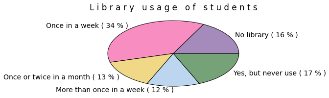

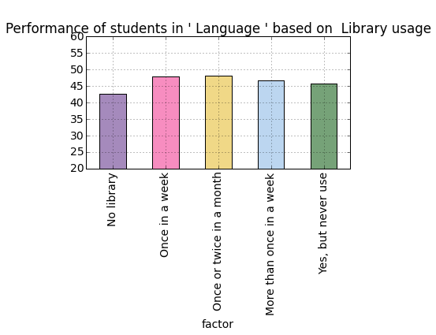

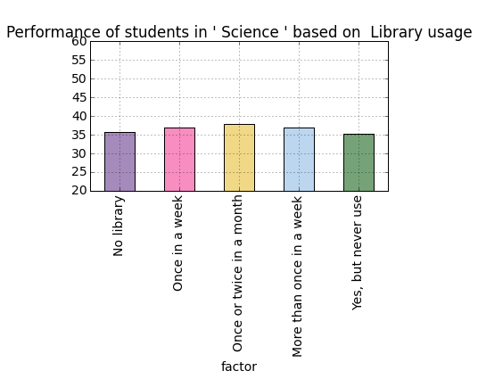

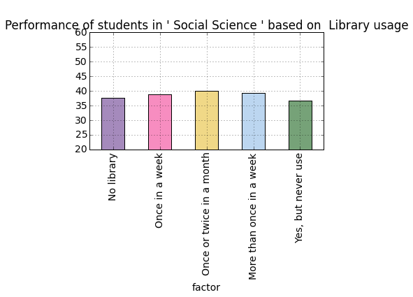

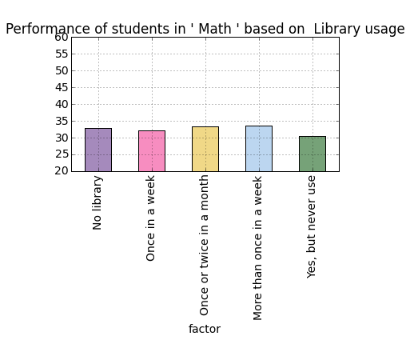

```python
#Performance of <subject> students depending on Library use
factor_vals = pd.Series(['No library','Once in a week', 'Once or twice in a month','More than once in a week','Yes, but never use'])
pie_colors =('#a58abc','#f78dc0','#f0d887','#bcd6f0','#76a278')
factor_name      = 'Library usage'
factor_ques = 'PQ15'

piechart_on = True
for sub in subjects_df.iterrows():
    ptitle = ' '.join(map(str,('Library usage of students')))
    btitle = ' '.join(map(str,("\nPerformance of students in '",sub[1]['Subject'],"' based on ", factor_name)))
    students_by_factor_analysis(sub[1]['Subject'],sub[1]['Subject-Perf'], factor_ques, factor_vals, pie_colors, ptitle, piechart_on,btitle, True)
    if(piechart_on == True):
        piechart_on = False
```

### Effect of Age on performance of students

The age of the students ranges from 11 to 16 and above. Thirteen is the average age of an 8th grade student, which is the grade this test is administered to. However, many younger students may end up in higher grades than they are supposed to be in. This could be because parents often wish to push their children into higher grades so they complete their education faster. It could be due to a feeling of acheivement when their children are ahead of their peers.

Students older than 13 may be in 8th grade because they may not have been able to keep up academically. This may have caused them to be held back to repeat the grade. Some of the students in Governemnt schools may also join school late, which would contribute to the number of students above the normal age for a grade.

As seen in the bar graph below, the 13 year olds did best and as students' age deviates from 13, they do increasingly worse. The 16 year olds and above do the worst, perhaps because they are behind academically and have hence been held back.

However in math, there is hardly any difference seen between any of the age groups, except for the 16 and above category which does worst.

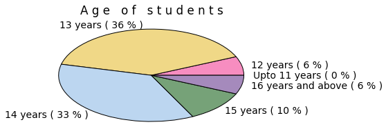

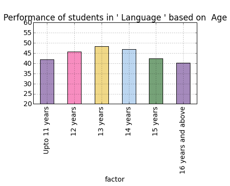

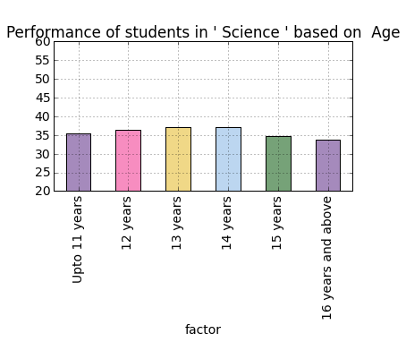

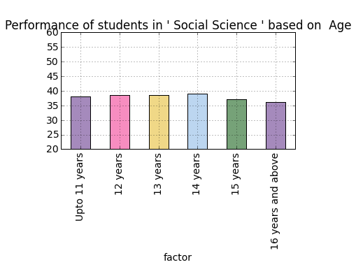

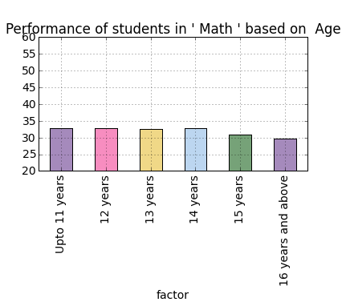

```python
#Performance of <subject> students depending on Age
factor_vals = pd.Series(['Upto 11 years','12 years','13 years', '14 years','15 years','16 years and above'])
pie_colors =('#a58abc','#f78dc0','#f0d887','#bcd6f0','#76a278')
factor_name      = 'Age'
factor_ques = 'PQ3'

piechart_on = True
for sub in subjects_df.iterrows():
    ptitle = ' '.join(map(str,('Age of students')))
    btitle = ' '.join(map(str,("\nPerformance of students in '",sub[1]['Subject'],"' based on ", factor_name)))
    students_by_factor_analysis(sub[1]['Subject'],sub[1]['Subject-Perf'], factor_ques, factor_vals, pie_colors, ptitle, piechart_on,btitle, True)
    if(piechart_on == True):
        piechart_on = False
```

### Effect of Playing Sports on Student Performance

This parameter has data on how often students play games and sports. It is categorised into Everyday, Once-a-week, Once-a-month and Never.

As seen in the pie chart below, 34% of the students play sports everyday, 34% play sports once a week, 11% play once a month and 13% never played sports.

The bar chart compares the students' performance in various subjects based on the amount of sports they play. The children who never played consistently did the worst and students who played once a week did the best. The variation is not very high, however.

As in other categories, it is likely that causation is not implied by correlation. Students who play once a week performed better than students who play everyday. This could be because the parents of students who play everyday are less insistent on academic focus and effort and hence allow them to play more. The students who never play did the worst. This is perhaps because the students who never play are those who have home situations that are less conducive to playing sports as well as to focussing on studies. Factors could be economic status and importance given to education by parents.

Students who played everyday didn't do as well as those who played once a week. This is probably because playing sports helps students in their overall physical and mental wellbeing but excessive playing probably means they spend less time on their studies.

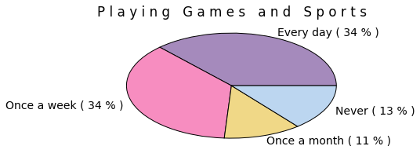

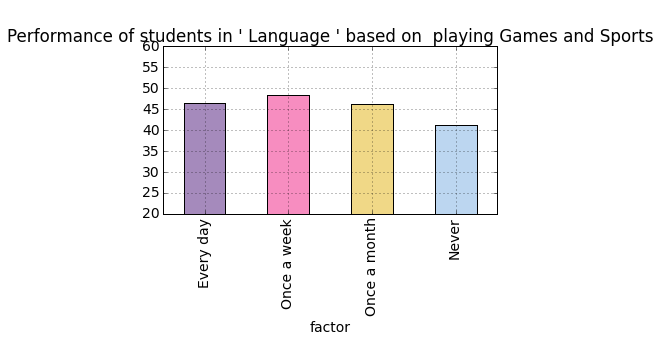

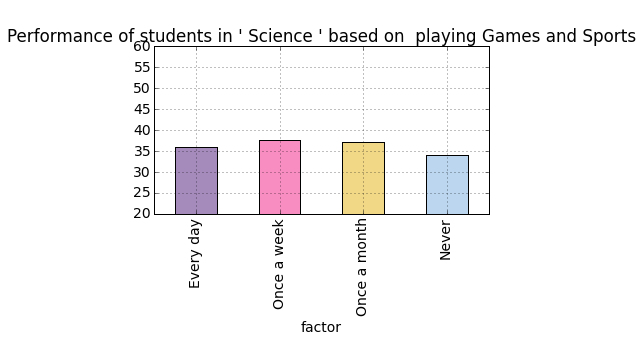

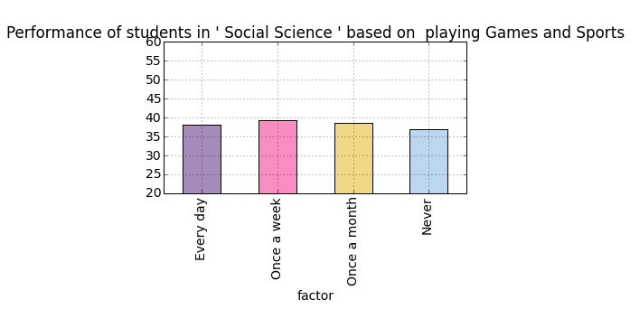

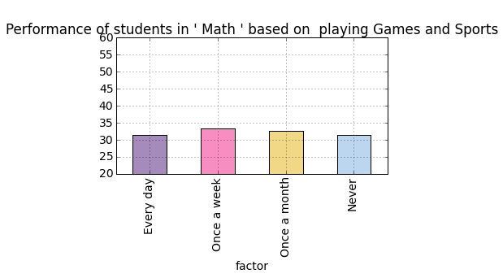

```python
#Performance of <subject> students depending on Play Games/Sports
factor_vals = pd.Series(['Every day','Once a week', 'Once a month', 'Never'])
pie_colors =('#a58abc','#f78dc0','#f0d887','#bcd6f0')
factor_name      = 'playing Games and Sports'
factor_ques = 'PQ26c'

piechart_on = True
for sub in subjects_df.iterrows():
    ptitle = ' '.join(map(str,('Playing Games and Sports')))
    btitle = ' '.join(map(str,("\nPerformance of students in '",sub[1]['Subject'],"' based on ", factor_name)))
    students_by_factor_analysis(sub[1]['Subject'],sub[1]['Subject-Perf'], factor_ques, factor_vals, pie_colors, ptitle, piechart_on,btitle, True)
    if(piechart_on == True):
        piechart_on = False
```

### Conclusion:

There were some expected findings but there were some surprising ones as well.

The students who watched TV performed better than students who did not watch TV at all, though this implies a correlation between TV watching and school performance, TV watching might not be the underlying cause. The hidden variable that is causing both TV watching behavior and better test performance is perhaps the financial stability of the family.

As expected, parents' education level is closely correlated with their children's performance. There are studies that show involvement of parents in their child's education leads to improved outcomes [Ref 4]. The data indicates that the fathers are more educated than the mothers at various education levels.

The analysis shows that students engaged in sports and games showed better performance in the asset test. However students who played everyday did worse than those who played only once a week, similar to the TV watching behavior and resultant performance.

With respect to the age of the students, the 13yr-olds did best which is also the mean age of 8th grade students. As the age of the students deviated from the norm, their performance worsened.

### Tools Used in the study

I used Python programming language in conjunction with iPython Notebook and the Pandas statistical package. All the plotting has been done using mathplotlib. The map visualizations were created using ArcMap(thanks to my dad who helped with this).

### References

1) A study from Human rights watch showing the dropout rate in India. (http://www.hrw.org/news/2014/04/22/qa-talking-discrimination-and-school-dropout-rates-india).

2) The National Achievement Survey 2014: (http://www.ncert.nic.in/departments/nie/esd/pdf/NAS_8_cycle3.pdf)

3) What Students of Class VIII Know and Can Do - A summary of India's National Assessment Survey, Class VIII, 2012 (http://ssa.nic.in/NAS/national-achievement-survey-class-iv/11%20March%20National%20Summary%20Report%20NAS%20Class%20VIII.pdf)

4) Parents Involvement in the Education of their Children: Indicators of Level of Involvement(http://www.ernape.net/ejournal/index.php/IJPE/article/viewFile/114/74)